# The forecaster’s toolbox

##### usdeaths

Monthly accidental deaths in USA.

###### no transformation

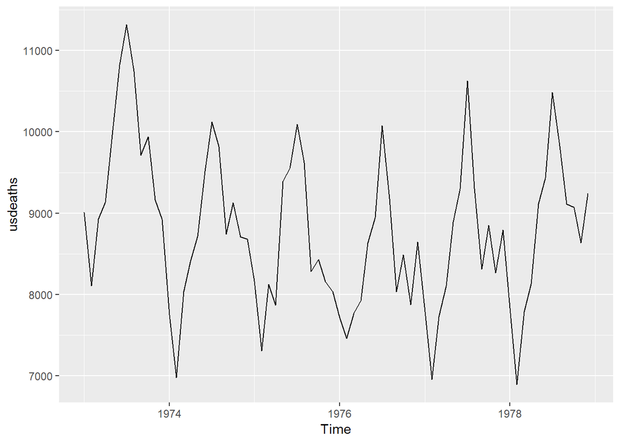

```r
autoplot(usdeaths)
```

###### transformation

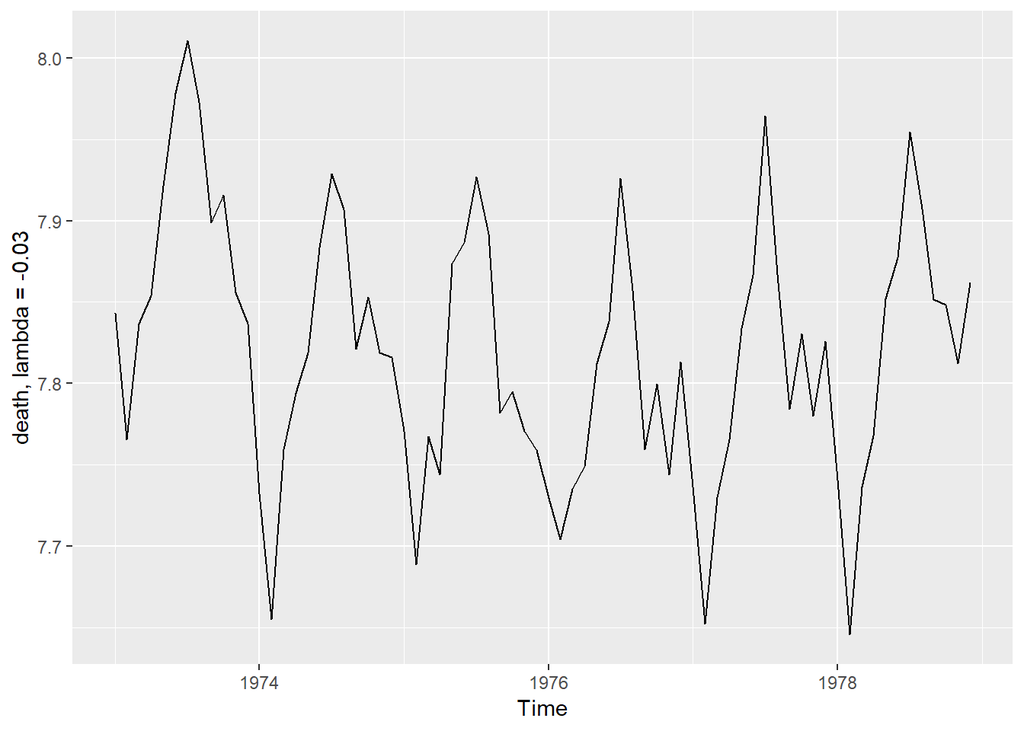

```r
lambda <- BoxCox.lambda(usdeaths)
usdeaths %>% BoxCox(lambda) %>% autoplot() + ylab(paste("death, lambda =", round(lambda, 2)))
```

##### bricksq

Australian quarterly clay brick production: 1956–1994.

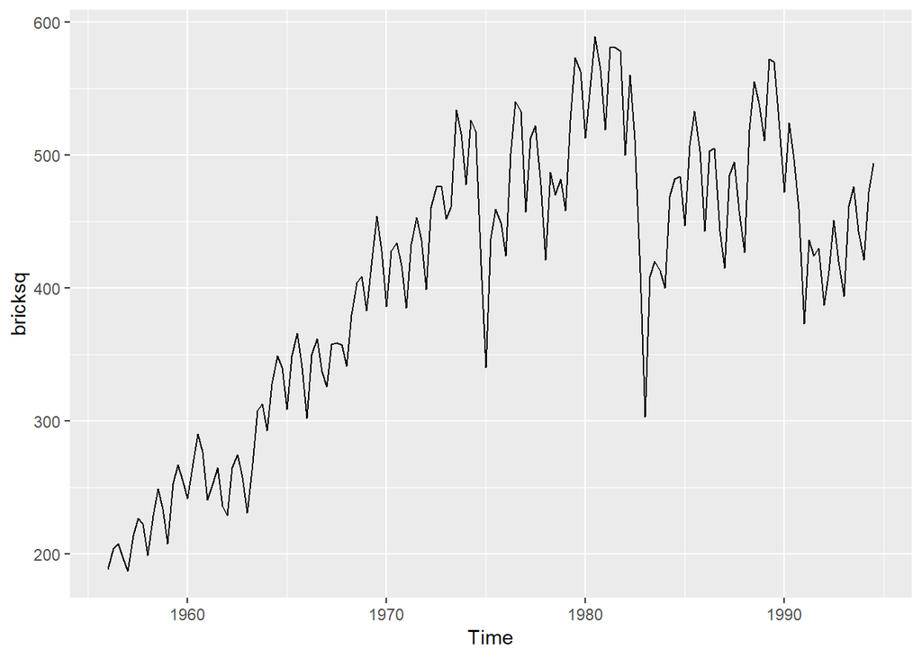

```r
autoplot(bricksq)
```

The time series was transformed using a Box-Cox transformation with λ=0.25. The transformation has stabilized the variance.

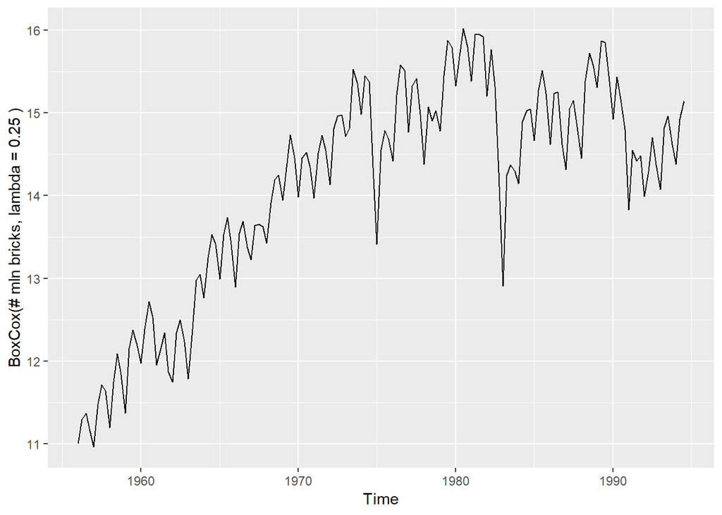

```r
lambda <- BoxCox.lambda(bricksq)
bricksq %>% BoxCox(lambda) %>% autoplot() + ylab(paste("BoxCox(# mln bricks, lambda =", round(lambda, 2), ")"))
```

### 5. Calculate the residuals from a seasonal naïve forecast applied to the quarterly Australian beer production data from 1992. The following code will help.

##### plot and visualization

```r
beer <- window(ausbeer, start=1992)
```

###### Seasonal naive method

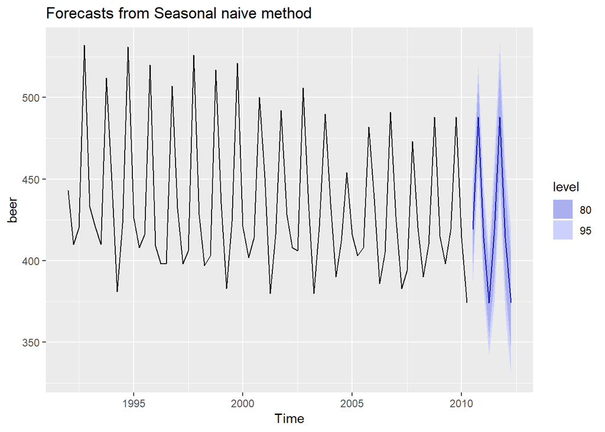

```r
fc <- snaive(beer)
autoplot(fc)
```

###### ploting errors

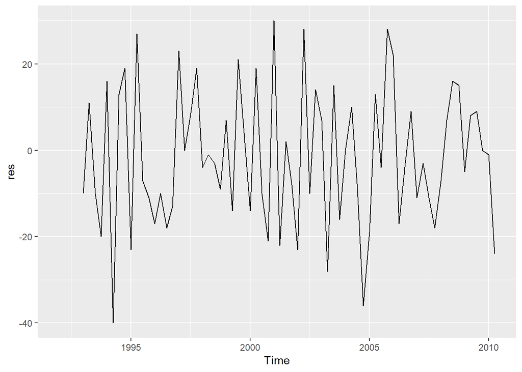

```r
res <- residuals(fc)
autoplot(res)
```

##### Checking residuals

Test if the residuals are white noise and normally distributed.

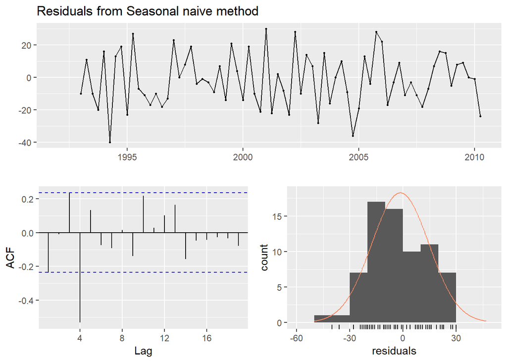

```
##
##  Ljung-Box test
##
## data:  Residuals from Seasonal naive method
## Q* = 32.269, df = 8, p-value = 8.336e-05
##
## Model df: 0.   Total lags used: 8
```

```r
checkresiduals(fc)
```

What do you conclude?

The residuals are correlated: the Null of no joint autocorrelation is clearly rejected. We can also see a significant spike on the seasonal (4th lag) in the ACF. There is considerable information remaining in the residuals which has not been captured with the seasonal naïve method. The residuals do not appear to be too far from Normally distributed.

### 6. Repeat the exercise for the WWWusage and bricksq data. Use whichever of naive() or snaive() is more appropriate in each case.

##### WWWusage

A time series of the numbers of users connected to the Internet through a server every minute.

###### autoplot

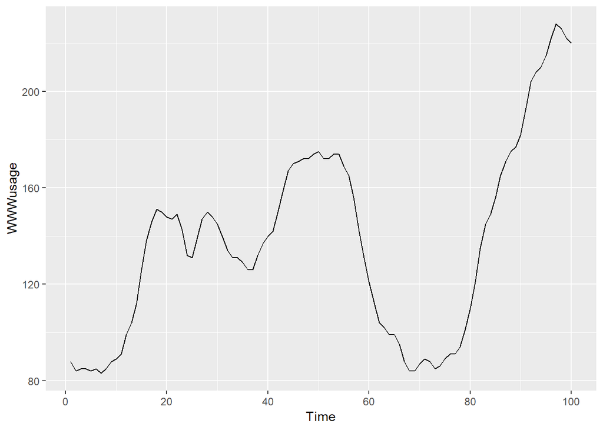

```r
autoplot(WWWusage)
```

###### pred: naive method

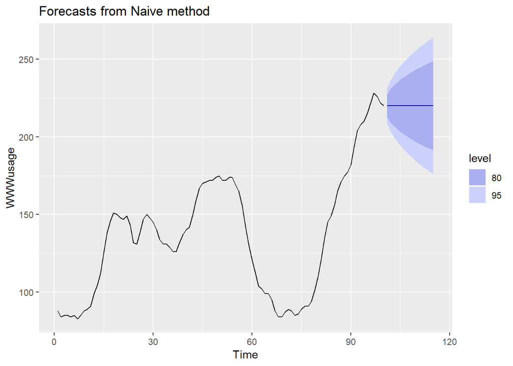

```r
fr_n <- naive(WWWusage, h = 15)
autoplot(fr_n)
```

###### error analysis naïve

Residuals are correlated as shown by both the LB test and the ACF. They seem to be normally distributed. There is considerable information remaining in the residuals which has not been captured with the naïve method.

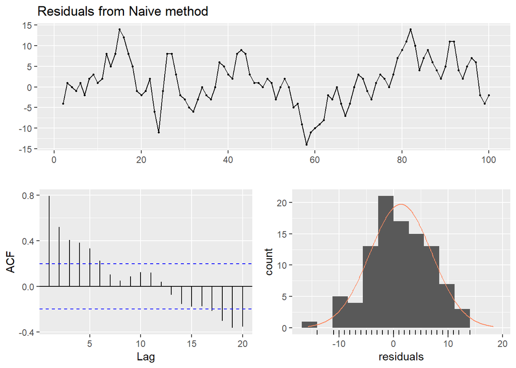

```
##
##  Ljung-Box test
##
## data:  Residuals from Naive method
## Q* = 145.58, df = 10, p-value < 2.2e-16
##
## Model df: 0.   Total lags used: 10
```

```r
checkresiduals(fr_n)
```

##### bricksq

Australian quarterly clay brick production: 1956–1994.

###### autoplot

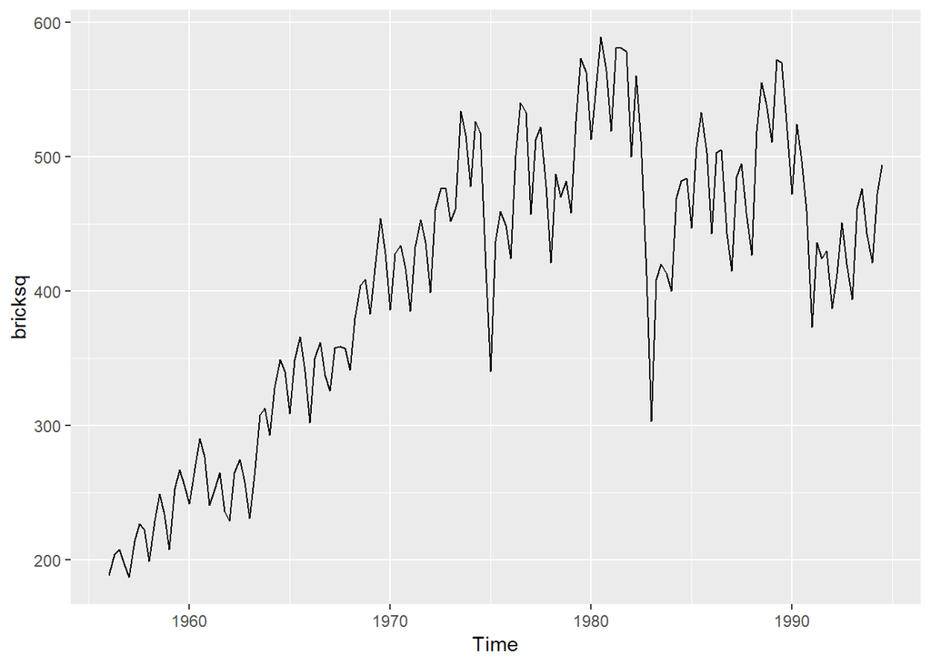

```r
autoplot(bricksq)
```

###### pred: seasonal naive method

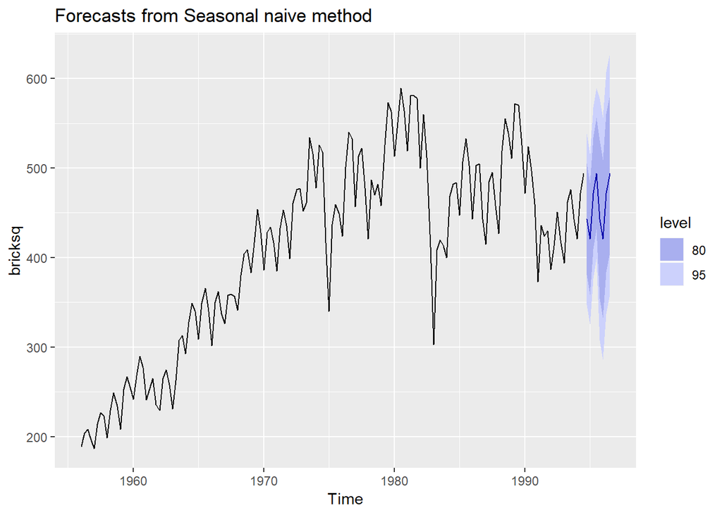

```r
fr_sn <- snaive(bricksq)
autoplot(fr_sn)
```

###### err. analysis seas.naïve

Residuals are correlated as shown by both the LB test and the ACF and do not appear to be normal (they have a long left tail). There is considerable information remaining in the residuals which has not been captured with the seasonal naïve method.

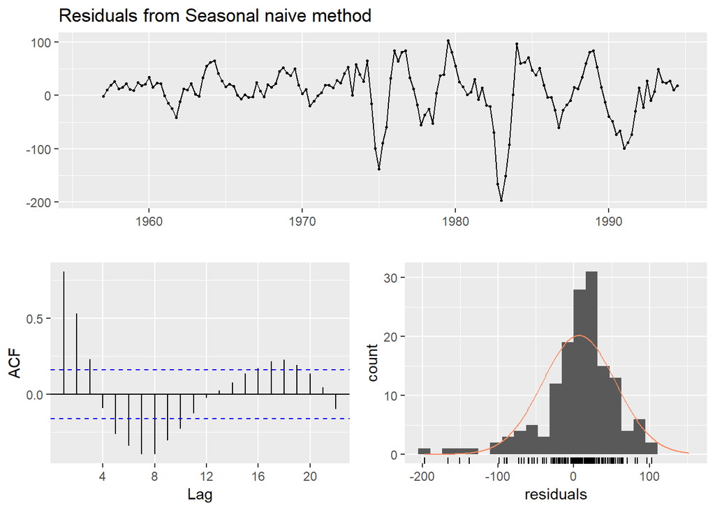

```
##
##  Ljung-Box test
##
## data:  Residuals from Seasonal naive method
## Q* = 233.2, df = 8, p-value < 2.2e-16
##
## Model df: 0.   Total lags used: 8
```

```r
checkresiduals(fr_sn)
```

### 7. Are the following statements true or false? Explain your answer.

1. Good forecast methods should have normally distributed residuals. FALSE

Not true. It is helpful to have normally distributed residuals because it makes the calculation of prediction intervals easier, and it means that least squares estimates of parameters are also equivalent (or close to) maximum likelihood estimates. But it doesn’t make the forecasts better. If the residuals are not normally-distributed, one way to produce prediction intervals is to use a bootstrapped approach.

2. A model with small residuals will give good forecasts. FALSE

Not true. An over-fitted model will have small residuals (relative to other models), but will probably not give good forecasts.

3. The best measure of forecast accuracy is MAPE. FALSE

Not true. MAPE is useful in some circumstances — for example, in comparing forecasts on different scales, or with different units, and is relatively easy to understand. But it is not appropriate if the data includes zeros, or if the data has no natural zero.

4. If your model doesn’t forecast well, you should make it more complicated. FALSE

Not true. Some things are hard to forecast, and making a model more complicated can make the forecasts worse.

5. Always choose the model with the best forecast accuracy as measured on the test set. FALSE

Not true. Imagine the test set has only a single observation, or a very small number of observations. We don’t want to select a model based on a small test set. A better approach is to use time-series cross-validation, which is based on a much larger set of test sets. Later, we will learn about the AIC statistic which is an alternative way to select a model and is often more helpful than a simple test set.

### 8. For your retail time series (from Exercise 3 in Section 2.10):

1. Split the data into two parts using

```r
myts.train <- window(myts, end=c(2010,12))
myts.test <- window(myts, start=2011)
```

2. Check that your data have been split appropriately by producing the following plot.

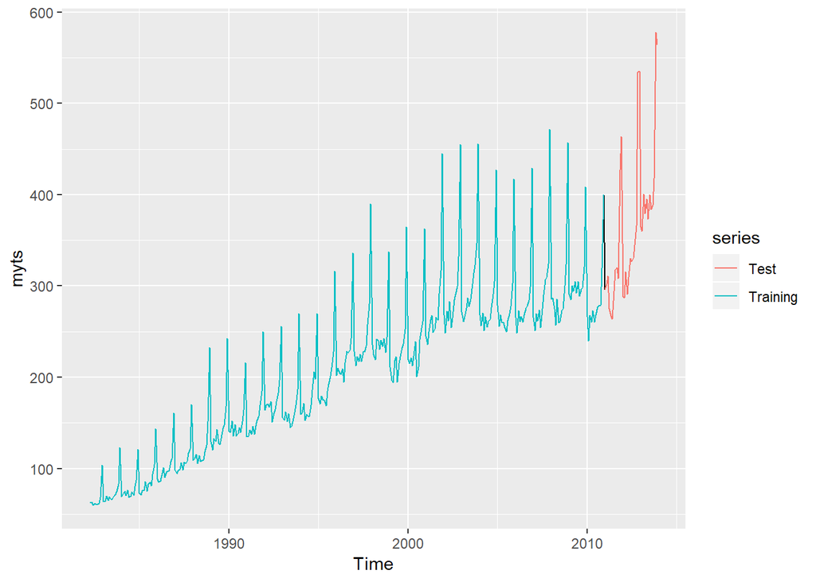

```r
autoplot(myts) +
  autolayer(myts.train, series="Training") +
  autolayer(myts.test, series="Test")
```

3. Calculate forecasts using snaive applied to myts.train.

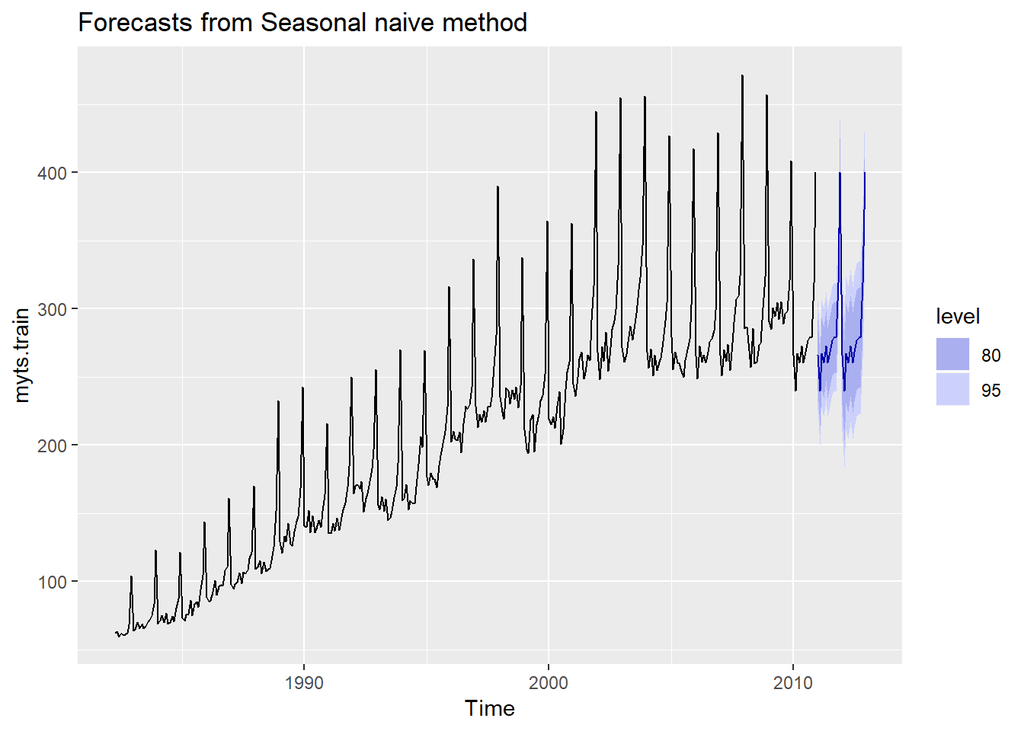

```r
fc <- snaive(myts.train)
autoplot(fc)
```

4. Compare the accuracy of your forecasts against the actual values stored in myts.test.

```r
kable(accuracy(fc,myts.test), format = "markdown")
```

|  | ME | RMSE | MAE | MPE | MAPE | MASE | ACF1 | Theil’s U |
| --- | --- | --- | --- | --- | --- | --- | --- | --- |
| Training set | 7.772973 | 20.24576 | 15.95676 | 4.702754 | 8.109777 | 1.000000 | 0.7385090 | NA |
| Test set | 55.300000 | 71.44309 | 55.78333 | 14.900996 | 15.082019 | 3.495907 | 0.5315239 | 1.297866 |

5. Check the residuals.

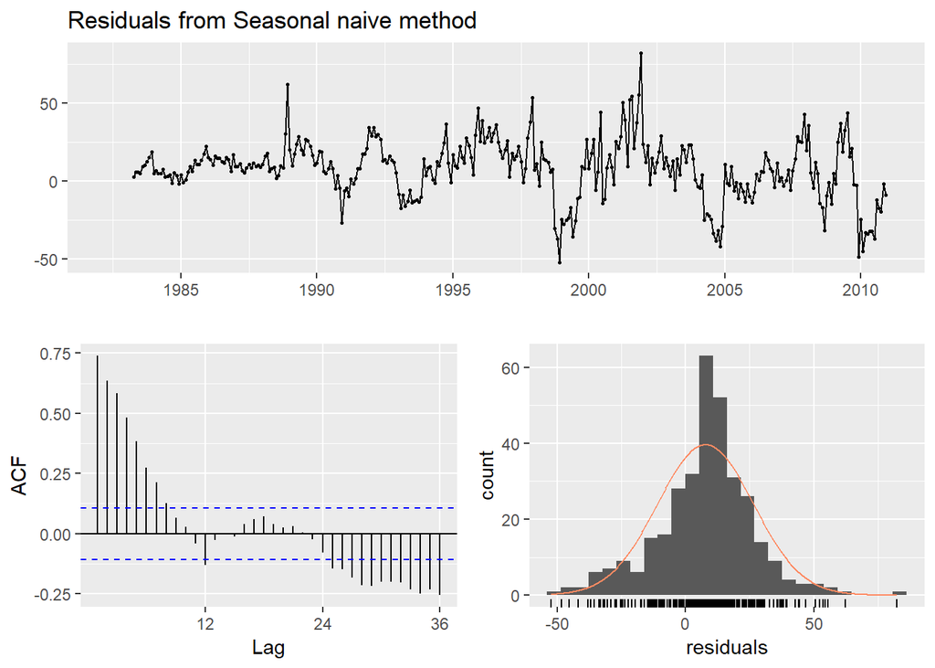

```
##
##  Ljung-Box test
##
## data:  Residuals from Seasonal naive method
## Q* = 624.45, df = 24, p-value < 2.2e-16
##
## Model df: 0.   Total lags used: 24
```

```r
checkresiduals(fc)
```

The residuals do not look like white noise there are lots of dynamics left over that need to be explored. They do look close to normal although the tails may be too long.

Do the residuals appear to be uncorrelated and normally distributed?

6. How sensitive are the accuracy measures to the training/test split?

The accuracy measure are always sensitive to this split. There are better ways to check the robustness of the methods in terms of accuracy such as using a rolling window (possible in this case as we have lots of data) or ts.cv.

### 9. “visnights” contains quarterly visitor nights (in millions) from 1998 to 2016 for twenty regions of Australia.

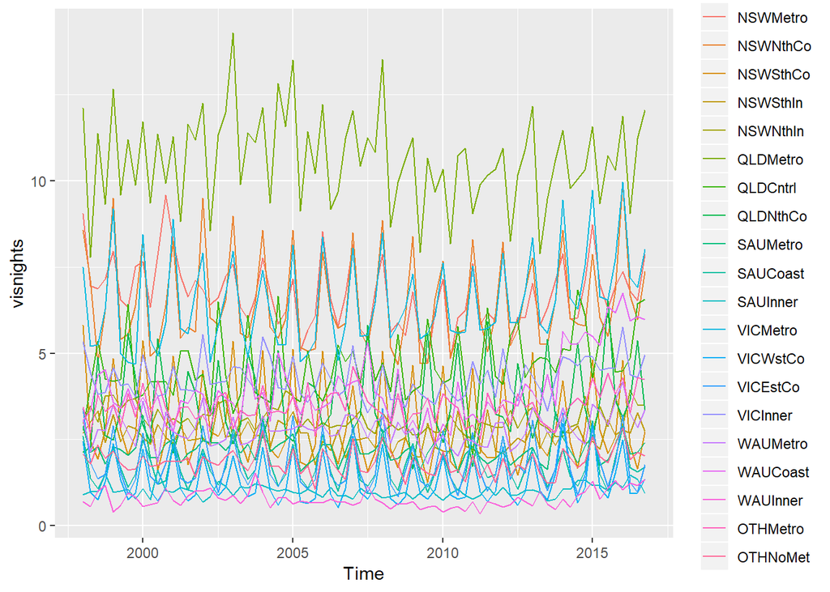

```r
autoplot(visnights)
```

```r
stats::start(visnights)
```

```
## [1] 1998    1
```

```r
stats::end(visnights)
```

```
## [1] 2016    4
```

```r
stats::frequency(visnights)
```

```
## [1] 4
```

##### a. Use window() to create three training sets for visnights[,“QLDMetro”], omitting the last 1, 2 and 3 years; call these train1, train2, and train3, respectively. For example:

###### end(2015, 4)

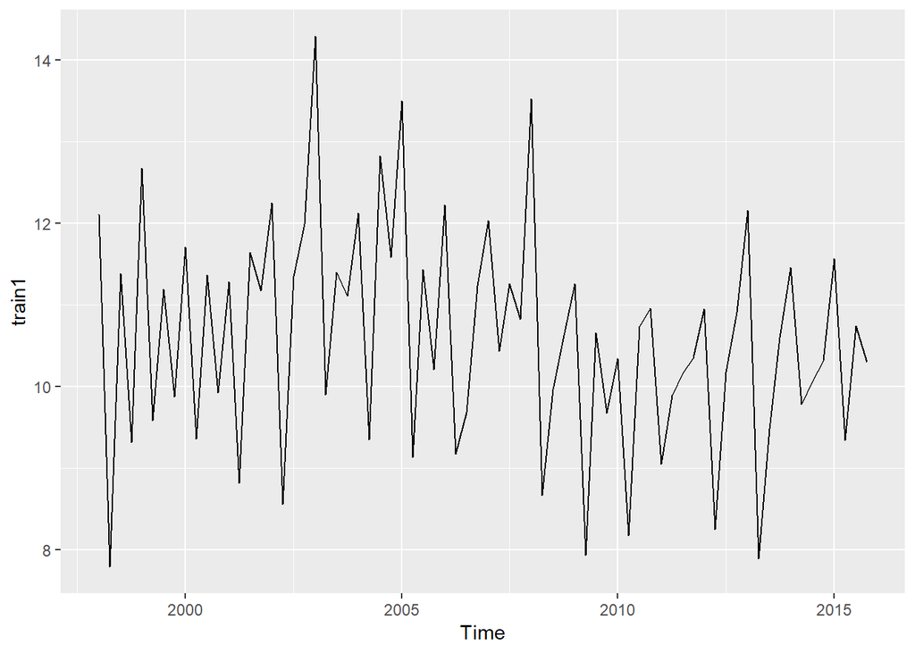

```r
train1 <- window(visnights[, "QLDMetro"], end = c(2015, 4))
test1 <- window(visnights[, "QLDMetro"], start = c(2016, 1))
autoplot(train1)
```

###### end(2014, 4)

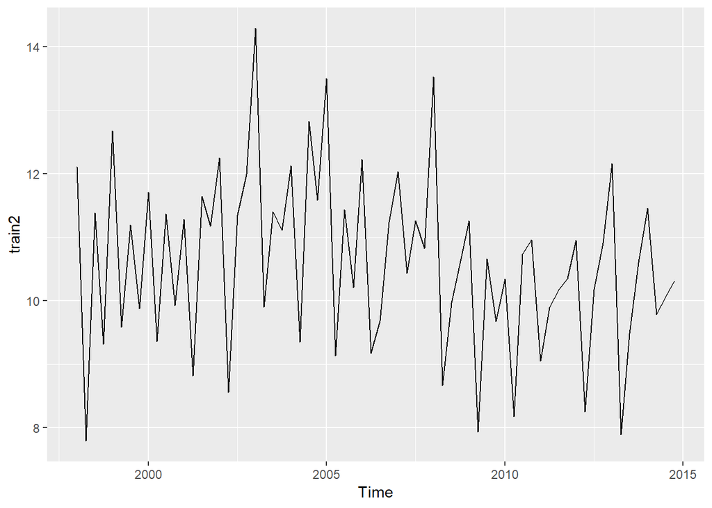

```r
train2 <- window(visnights[, "QLDMetro"], end = c(2014, 4))
test2 <- window(visnights[, "QLDMetro"], start = c(2015, 1))
autoplot(train2)
```

###### end(2013, 4)

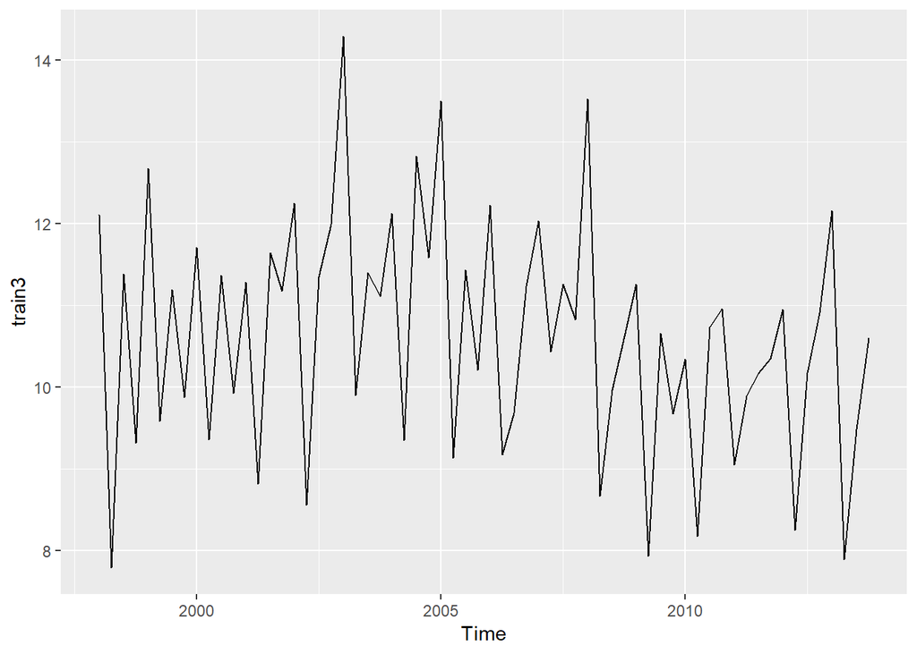

```r
train3 <- window(visnights[, "QLDMetro"], end = c(2013, 4))
test3 <- window(visnights[, "QLDMetro"], start = c(2014, 1))
autoplot(train3)
```

##### b. Compute one year of forecasts for each training set using the snaive() method. Call these fc1, fc2 and fc3, respectively.

###### 1y prediction

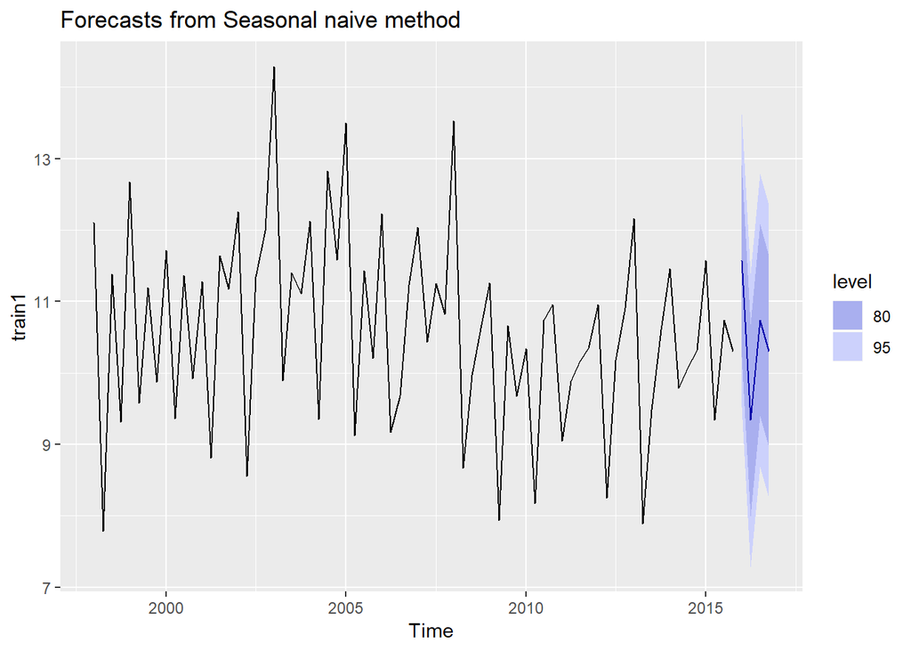

```r
fc1 <- snaive(train1, h = 4)
autoplot(fc1)
```

###### 2y prediction

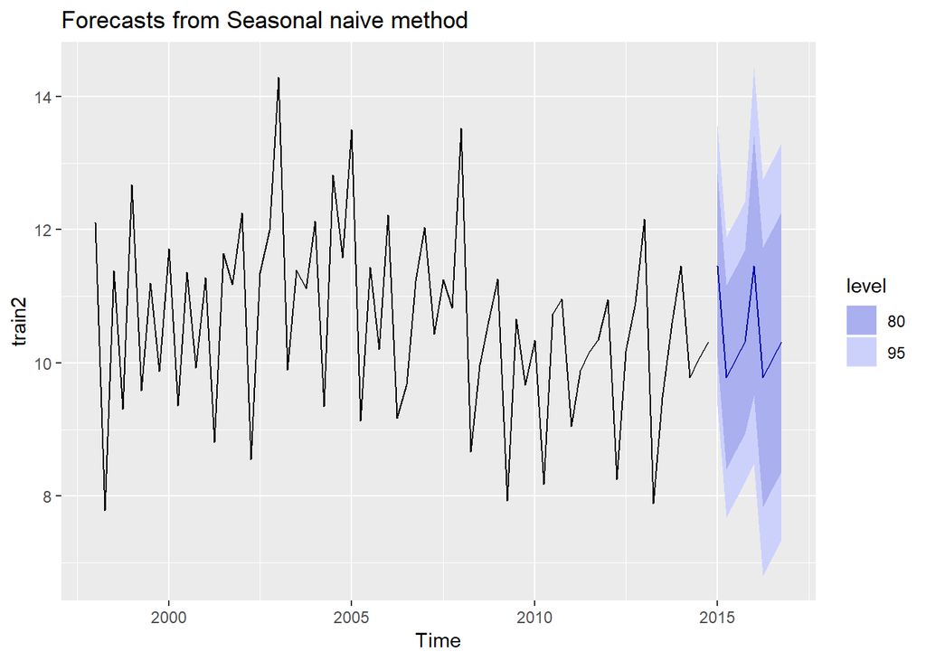

```r
fc2 <- snaive(train2, h = 8)
autoplot(fc2)
```

###### 3y prediction

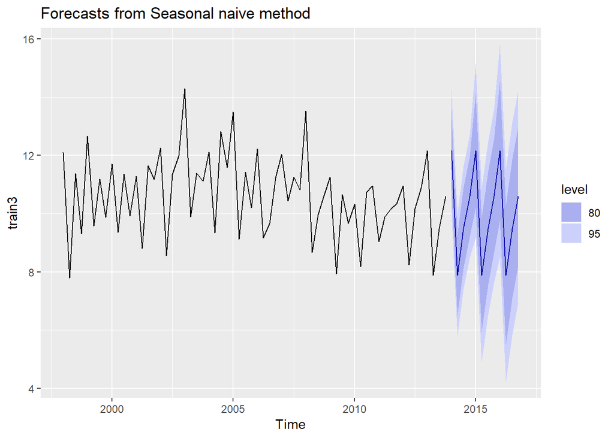

```r
fc3 <- snaive(train3, h = 12)
autoplot(fc3)
```

##### c. Use accuracy() to compare the MAPE over the three test sets. Comment on these.

###### predictions 1y

```r
kable(accuracy(fc1, test1), format = "markdown")
```

|  | ME | RMSE | MAE | MPE | MAPE | MASE | ACF1 | Theil’s U |
| --- | --- | --- | --- | --- | --- | --- | --- | --- |
| Training set | 0.0200611 | 1.0462821 | 0.8475553 | -0.2237701 | 7.976760 | 1.0000000 | 0.0601448 | NA |
| Test set | 0.5698388 | 0.9358727 | 0.7094002 | 4.6191866 | 6.159821 | 0.8369957 | 0.0900315 | 0.4842061 |

###### predictions 2y

```r
kable(accuracy(fc2, test2), format = "markdown")
```

|  | ME | RMSE | MAE | MPE | MAPE | MASE | ACF1 | Theil’s U |
| --- | --- | --- | --- | --- | --- | --- | --- | --- |
| Training set | 0.0161876 | 1.0735582 | 0.8809432 | -0.2744747 | 8.284216 | 1.0000000 | 0.0661088 | NA |
| Test set | 0.3669560 | 0.8516202 | 0.6644561 | 2.8431247 | 6.085501 | 0.7542553 | -0.0020210 | 0.5102527 |

###### predictions 3y

```r
kable(accuracy(fc3, test3), format = "markdown")
```

|  | ME | RMSE | MAE | MPE | MAPE | MASE | ACF1 | Theil’s U |
| --- | --- | --- | --- | --- | --- | --- | --- | --- |
| Training set | -0.0074554 | 1.074544 | 0.8821694 | -0.5625865 | 8.271365 | 1.000000 | 0.0731775 | NA |
| Test set | 0.6154700 | 1.125643 | 0.9744350 | 6.1253947 | 9.331107 | 1.104589 | 0.0229235 | 0.7439074 |

### 10. Use the Dow Jones index (data set “dowjones”) to do the following:

##### a. Produce a time plot of the series

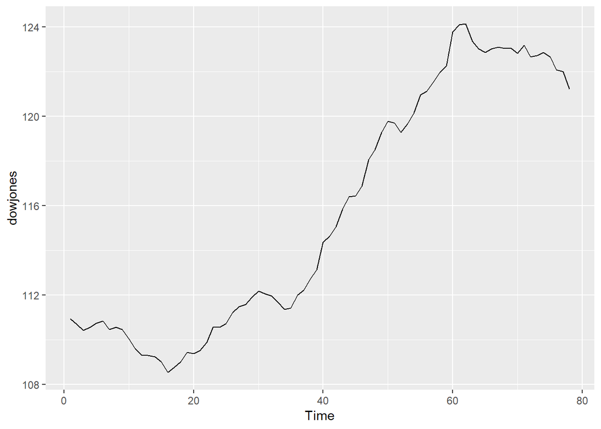

```r
autoplot(dowjones)
```

```r
start(dowjones)
```

```
## [1] 1 1
```

```r
end(dowjones)
```

```
## [1] 78  1
```

```r
frequency(dowjones)
```

```
## [1] 1
```

##### b. Produce forecasts using the drift method and plot them.

```r
fc.dj1 <- rwf(dowjones, h = 5, drift = T)
fc.dj2 <- rwf(dowjones, h = 10, drift = T)
fc.dj3 <- rwf(dowjones, h = 15, drift = T)
```

##### c. Show that the forecasts are identical to extending the line drawn between the first and last observations.

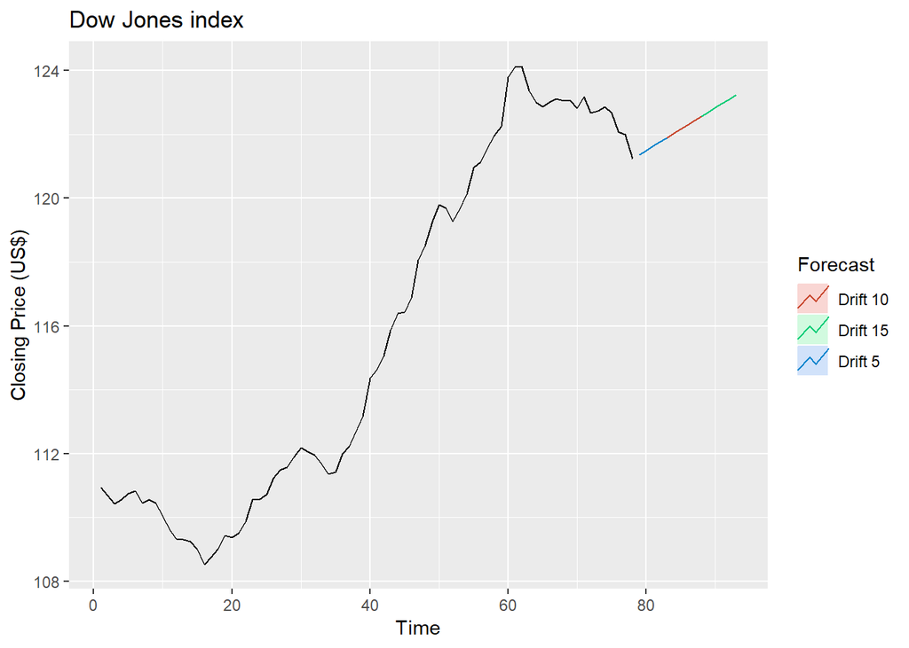

```r
autoplot(dowjones) +
  autolayer(fc.dj3, PI = F, series = "Drift 15") +
  autolayer(fc.dj2, PI = F, series = "Drift 10") +
  autolayer(fc.dj1, PI = F, series = "Drift 5") +
  xlab("Time") + ylab("Closing Price (US$)") +
  ggtitle("Dow Jones index") +
  guides(colour=guide_legend(title="Forecast"))
```

##### d. Try using some of the other benchmark functions to forecast the same data set. Which do you think is best? Why?

The time series isn’t seasonal, so the seasonal naïve method is not viable. However, we can use the mean and naïve methods.

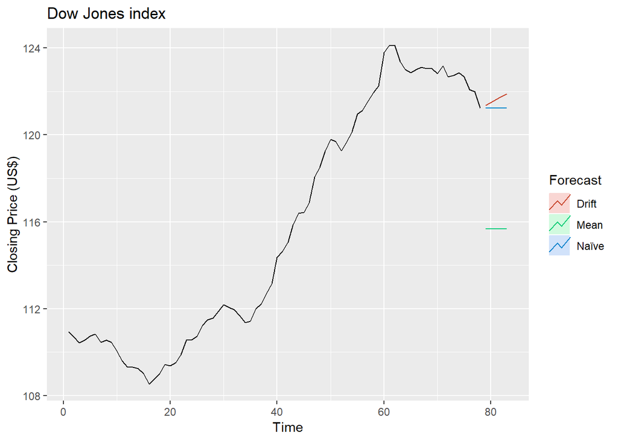

```r
fc.dw1 <- meanf(dowjones, h = 5)
fc.dw2 <- rwf(dowjones, h = 5)
fc.dw3 <- rwf(dowjones, drift = T, h = 5)
autoplot(dowjones) +
  autolayer(fc.dw1, PI = F, series = "Mean") +
  autolayer(fc.dw2, PI = F, series = "Naïve") +
  autolayer(fc.dw3, PI = F, series = "Drift") +
  xlab("Time") + ylab("Closing Price (US$)") +
  ggtitle("Dow Jones index") +
  guides(colour=guide_legend(title="Forecast"))
```

### 11. Consider the daily closing IBM stock prices (data set “ibmclose”).

##### a. Produce some plots of the data in order to become familiar with it.

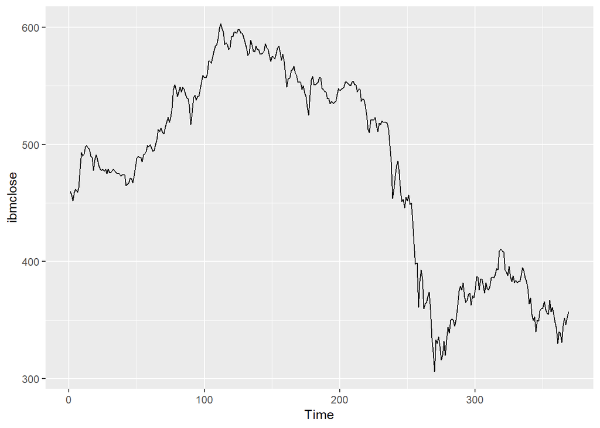

```r
autoplot(ibmclose)
```

##### b. Split the data into a training set of 300 observations and a test set of 69 observations.

green = training red = testing

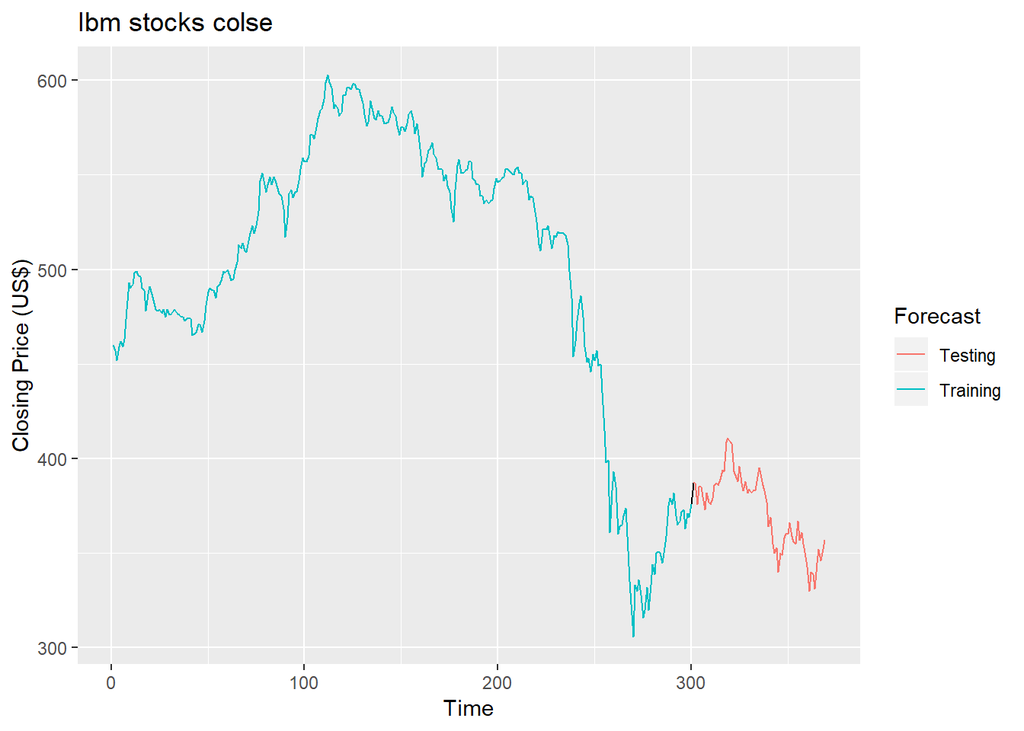

```r
train <- window(ibmclose, end = 300)
test <- window(ibmclose, start = 301)
autoplot(ibmclose) +
  autolayer(train, series = "Training") +
  autolayer(test, series = "Testing") +
  xlab("Time") + ylab("Closing Price (US$)") +
  ggtitle("Ibm stocks colse") +
  guides(colour=guide_legend(title="Forecast"))
```

##### c. Try using various benchmark methods to forecast the training set and compare the results on the test set. Which method did best?

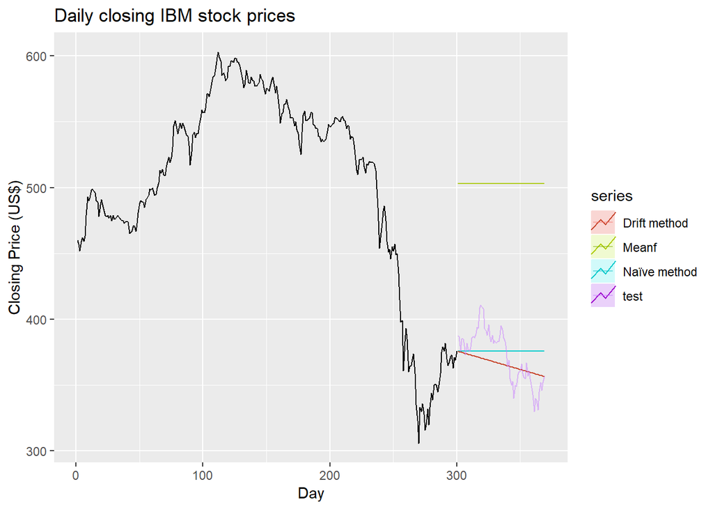

```r
# define the h paramether
h <- length(test)
fc.mf <- meanf(train, h = h)
fc.dr1 <- rwf(train, h = h)
fc.dr2 <- rwf(train, drift = T, h = h)

autoplot(train) +
  autolayer(fc.mf, PI = F,series = "Meanf") +
  autolayer(fc.dr1, PI = F, series = "Naïve method") +
  autolayer(fc.dr2, PI = F, series = "Drift method") +
  autolayer(test, alpha = 0.5) +
  xlab("Day") + ylab("Closing Price (US$)") +
  ggtitle("Daily closing IBM stock prices")
```

##### Forecast results

###### meanf

```r
kable(accuracy(fc.mf, test), format = "markdown")
```

|  | ME | RMSE | MAE | MPE | MAPE | MASE | ACF1 | Theil’s U |
| --- | --- | --- | --- | --- | --- | --- | --- | --- |
| Training set | 0.000 | 73.61532 | 58.72231 | -2.642058 | 13.03019 | 11.52098 | 0.9895779 | NA |
| Test set | -130.618 | 132.12557 | 130.61797 | -35.478819 | 35.47882 | 25.62649 | 0.9314689 | 19.05515 |

###### Naïve method

```r
kable(accuracy(fc.dr1, test), format = "markdown")
```

|  | ME | RMSE | MAE | MPE | MAPE | MASE | ACF1 | Theil’s U |
| --- | --- | --- | --- | --- | --- | --- | --- | --- |
| Training set | -0.2809365 | 7.302815 | 5.09699 | -0.0826287 | 1.115844 | 1.000000 | 0.1351052 | NA |
| Test set | -3.7246377 | 20.248099 | 17.02899 | -1.2939174 | 4.668186 | 3.340989 | 0.9314689 | 2.973486 |

###### Drift method

```r
kable(accuracy(fc.dr2, test), format = "markdown")
```

|  | ME | RMSE | MAE | MPE | MAPE | MASE | ACF1 | Theil’s U |
| --- | --- | --- | --- | --- | --- | --- | --- | --- |
| Training set | 0.000000 | 7.297409 | 5.127996 | -0.0253012 | 1.121650 | 1.006083 | 0.1351052 | NA |
| Test set | 6.108138 | 17.066963 | 13.974747 | 1.4192007 | 3.707888 | 2.741765 | 0.9045875 | 2.361092 |

In terms of accuracy measures on the test set, the drift method does better.

##### d. Check the residuals of your preferred method. Do they resemble white noise?

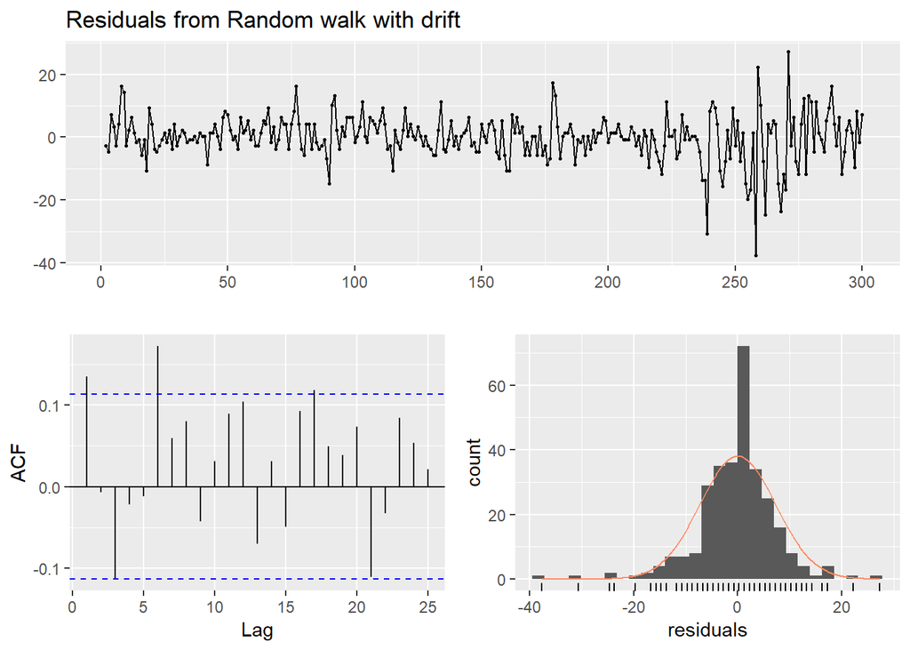

```
##
##  Ljung-Box test
##
## data:  Residuals from Random walk with drift
## Q* = 22.555, df = 9, p-value = 0.007278
##
## Model df: 1.   Total lags used: 10
```

```r
checkresiduals(fc.dr2)
```

```r
Box.test(residuals(fc.dr2),
         type="Lj", #test to be performed: partial matching is used.
         lag = 10, #the statistic will be based on lag autocorrelation coefficients.
         fitdf=1) #number of degrees of freedom to be subtracted if x is a series of residuals.
```

```
##
##  Box-Ljung test
##
## data:  residuals(fc.dr2)
## X-squared = 22.555, df = 9, p-value = 0.007278
```

### 12. Consider the sales of new one-family houses in the USA, Jan 1973 – Nov 1995 (data set hsales).

##### a. Produce some plots of the data in order to become familiar with it.

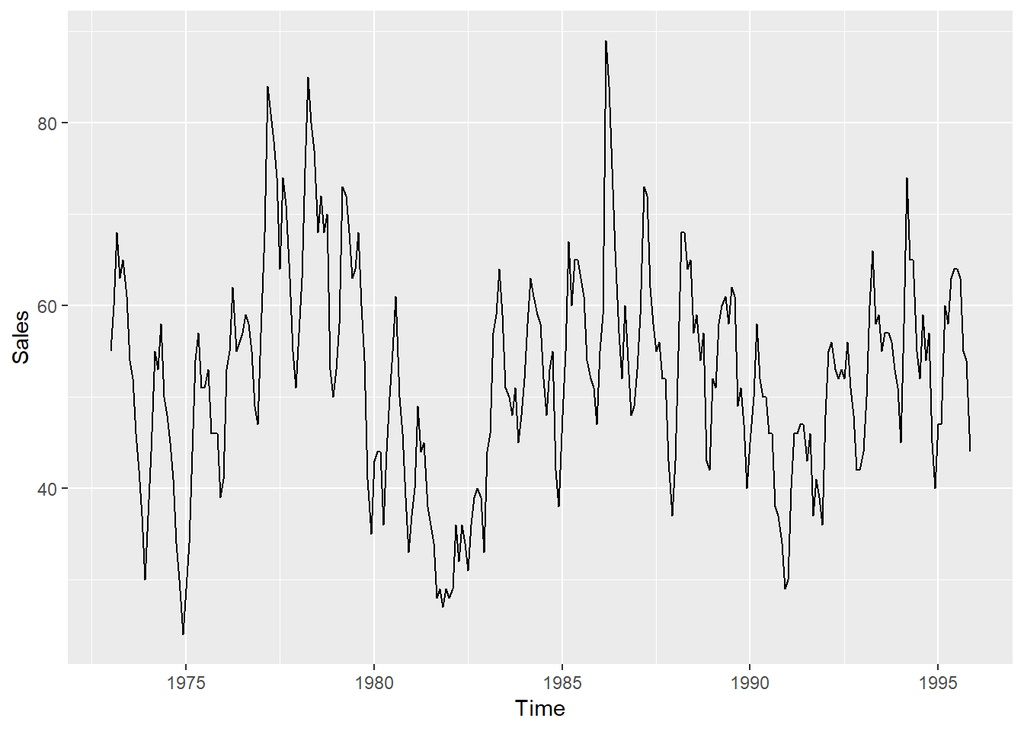

```r
autoplot(hsales) + ylab("Sales")
```

##### b. Split the “hsales” data set into a training set and a test set, where the test set is the last two years of data.

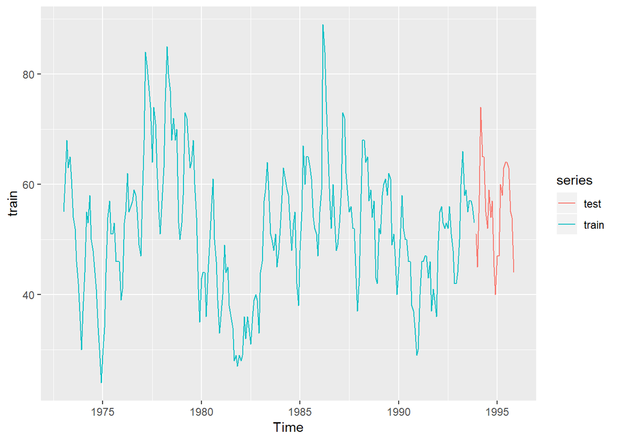

```r
train <- window(hsales, end = c(1993, 11))
test <- window(hsales, start = c(1993, 12))
autoplot(train, series = "train") +
  autolayer(test, series = "test")
```

##### c. Try using various benchmark methods to forecast the training set and compare the results on the test set. Which method did best?

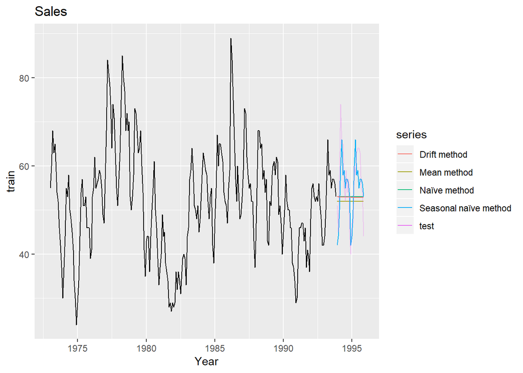

```r
h <- length(test)
m.f <- meanf(train, h=h)
rw.f <- rwf(train, h=h)
sn.f <- snaive(train, h=h)
rwd.f <- rwf(train, drift=TRUE, h=h)

autoplot(train) +
  xlab("Year") +
  ggtitle("Sales") +
  autolayer(m.f$mean, col=2, series="Mean method") +
  autolayer(rw.f$mean, col=3, series="Naïve method") +
  autolayer(sn.f$mean, col=4, series="Seasonal naïve method") +
  autolayer(rwd.f$mean, col=5, series="Drift method") +
  autolayer(test, alpha = 0.30)
```

##### Forecast results

###### meanf

```r
kable(accuracy(m.f, test), format = "markdown")
```

|  | ME | RMSE | MAE | MPE | MAPE | MASE | ACF1 | Theil’s U |
| --- | --- | --- | --- | --- | --- | --- | --- | --- |
| Training set | 0.000000 | 12.162811 | 9.532738 | -6.144876 | 20.38306 | 1.1234341 | 0.8661998 | NA |
| Test set | 3.839475 | 9.022555 | 7.561587 | 4.779121 | 13.26183 | 0.8911338 | 0.5377994 | 1.131713 |

###### Naïve method

```r
kable(accuracy(rw.f, test), format = "markdown")
```

|  | ME | RMSE | MAE | MPE | MAPE | MASE | ACF1 | Theil’s U |
| --- | --- | --- | --- | --- | --- | --- | --- | --- |
| Training set | -0.008000 | 6.301111 | 5.000000 | -0.767457 | 9.903992 | 0.5892505 | 0.1824472 | NA |
| Test set | 2.791667 | 8.628924 | 7.208333 | 2.858639 | 12.849194 | 0.8495028 | 0.5377994 | 1.098358 |

###### Seasonal naïve method

```r
kable(accuracy(sn.f, test), format = "markdown")
```

|  | ME | RMSE | MAE | MPE | MAPE | MASE | ACF1 | Theil’s U |
| --- | --- | --- | --- | --- | --- | --- | --- | --- |
| Training set | 0.1004184 | 10.582214 | 8.485356 | -2.184268 | 17.633696 | 1.0000000 | 0.8369786 | NA |
| Test set | 1.0416667 | 5.905506 | 4.791667 | 0.972025 | 8.545729 | 0.5646984 | 0.1687797 | 0.7091534 |

###### Drift method

```r
kable(accuracy(rwd.f, test), format = "markdown")
```

|  | ME | RMSE | MAE | MPE | MAPE | MASE | ACF1 | Theil’s U |
| --- | --- | --- | --- | --- | --- | --- | --- | --- |
| Training set | 0.000000 | 6.301106 | 4.999872 | -0.7511048 | 9.903063 | 0.5892354 | 0.1824472 | NA |
| Test set | 2.891667 | 8.658795 | 7.249000 | 3.0426108 | 12.901696 | 0.8542954 | 0.5378711 | 1.100276 |

##### d. Check the residuals of your preferred method. Do they resemble white noise?

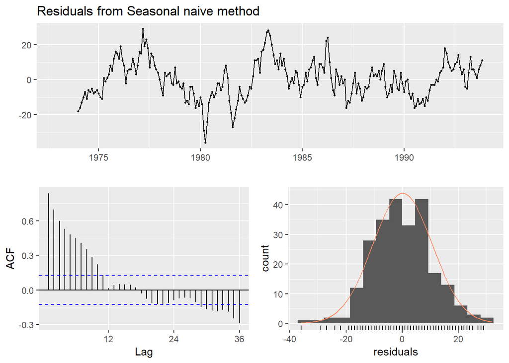

```
##
##  Ljung-Box test
##
## data:  Residuals from Seasonal naive method
## Q* = 682.2, df = 24, p-value < 2.2e-16
##
## Model df: 0.   Total lags used: 24
```

```r
checkresiduals(sn.f)
```